# Manejo de fechas en R

Jorge de la Vega

7/10/2021

# Introducción

EL manejo de fechas es siempre difícil por la cantidad de formatos que hay disponibles, adicionalmente a las zonas horarias, los años bisiestos, la inclusión de los días, las horas, minutos y sus fracciones, los tiempos para ahorro de energía,etc.

# Funciones básicas para manejo de fechas

- La función básica `as.Date` maneja fechas sin tiempos, y donde el formato se puede especificar con el argumento `format=`. El formato por default es `aaaa-mm-dd` o `aaaa/mm/dd`

```r
(a <- as.Date("2021/10/07"))
```

```
## [1] "2021-10-07"
```

```r
(b <- as.Date("2021/10/01"))
```

```
## [1] "2021-10-01"
```

```r
a-b
```

```
## Time difference of 6 days
```

```r
b-a
```

```
## Time difference of -6 days
```

```r
a-10
```

```
## [1] "2021-09-27"
```

```r
a+b  # no está definido
```

```
## Error in `+.Date`(a, b): binary + is not defined for "Date" objects
```

El formato se especifica con códigos. La lista completa de códigos es muy larga, y se puede encontrar en el help. Aquí pongo ejemplos:

| Codigo | Valor |
| --- | --- |
| %d | día del mes |
| %m | mes |
| %b | mes (abreviado) |
| %B | mes (completo) |
| %y | año (2 dígitos) |
| %Y | año (4 dígitos) |

Ejemplos de uso:

```r
as.Date("1/15/2001", format = "%m/%d/%Y")
```

```
## [1] "2001-01-15"
```

```r
as.Date("abril 26, 2001", format = "%B %d, %Y")
```

```
## [1] "2001-04-26"
```

```r
as.Date("22JUN01",format = "%d%b%y")
```

```
## [1] "2001-06-22"
```

Como pasa en Excel, los objetos `Date` son representados como número de días desde **el 1 de enero de 1970** , usando números negativos para fechas anteriores.

```r
# Convierte una fecha a su representación numérica:
as.numeric(as.Date("1970/1/1"))
```

```
## [1] 0
```

```r
a <- as.Date("1968/12/06")
a <- as.numeric(a)
a
```

```
## [1] -391
```

```r
class(a) <- "Date"  # convierte un número a fecha
a
```

```
## [1] "1968-12-06"
```

Para extraer componentes de una fecha se pueden usar las funciones `weekdays`, `months`,`quarters`.

```r
a <- as.Date("2021/10/07")
weekdays(a)
```

```
## [1] "jueves"
```

```r
months(a)
```

```
## [1] "octubre"
```

```r
quarters(a)
```

```
## [1] "Q4"
```

# Usando el paquete `lubridate`

No es parte de `tidyverse` pero es primo cercano. Aquí se cargarán los paquetes necesarios y un conjunto de datos para practicar

```r
library(tidyverse)
library(lubridate)
library(nycflights13) # Carga un archivo de datos para practicar
```

```r
today() # función en lubridate
```

```
## [1] "2021-10-07"
```

```r
now()   # incluye el tiempo
```

```
## [1] "2021-10-07 13:46:31 CDT"
```

Para convertir cadenas en fechas con `lubridate`, se pueden usar las funciones `ymd` o `myd` o `dmy` o etc. según el orden en que aparezcan en la cadena (hay 6 ordenamientos posibles):

```r
ymd("2021/10/07")
```

```
## [1] "2021-10-07"
```

```r
mdy("octubre 2, 1968")
```

```
## [1] "1968-10-02"
```

```r
dym("31-2021-10")
```

```
## [1] "2021-10-31"
```

```r
ydm("10/10/10")  # hay formatos con los que hay que tener claridad.
```

```
## [1] "2010-10-10"
```

Para crear fechas con tiempos, se puede añadir una o más de las letras h, m o s, y una zona de tiempo (son muy difíciles de manejar en general, dependen del sistema operativo).

```r
Sys.timezone() # revisa cuál es la configuración de la computadora utilizada
```

```
## [1] "America/Mexico_City"
```

```r
ymd_hms("2021/10/07 23:23:23", tz=Sys.timezone())
```

```
## [1] "2021-10-07 23:23:23 CDT"
```

## Ejemplo práctico

Utilizaré el archivo sobre https://datos.cdmx.gob.mx/dataset/capacidad-hospitalaria en la ZMVM que es parte del portal de datos abiertos, para mostrar cómo podemos encontrarnos fechas y convertir los datos a series de tiempo

```r
datos <- read.csv("https://datos.cdmx.gob.mx/dataset/9c45ead6-9016-469a-b6ba-41e3660590cb/resource/c97a1898-5343-4b01-8d76-9f74e5b0d072/download/capacidad_hospitalaria_micrositio.csv")
str(datos)  # ver la estructura de los datos
```

```
## 'data.frame':    42907 obs. of  6 variables:
##  $ Fecha                         : chr  "2020-06-13" "2020-06-13" "2020-06-13" "2020-06-13" ...
##  $ Nombre_hospital               : chr  "HOSPITAL GENERAL DE AXAPUSCO" "HOSPITAL GENERAL AMECAMECA \"VALENTIN GOMEZ FARIAS\"" "HOSPITAL GENERAL VALLE DE CHALCO \"DR. FERNANDO QUIROZ GUTIERREZ\"" "HOSPITAL GENERAL TEXCOCO \"GUADALUPE VICTORIA\" BICENTENARIO" ...
##  $ Institucion                   : chr  "EDOMEX" "EDOMEX" "EDOMEX" "EDOMEX" ...
##  $ Estatus_capacidad_hospitalaria: chr  "Crítica" "Buena" "Buena" "Media" ...
##  $ Estatus_capacidad_UCI         : chr  "Crítica" "Buena" "Buena" "Buena" ...
##  $ Coordenadas                   : chr  "19.732872,-98.769445" "19.144883,-98.785072" "19.273775,-98.941609" "19.514309,-98.871750" ...
```

Notamos que la primera columna nos da la fecha, ya en el formato adecuado. Si convertimos la variable categórica `Estatus_capacidad_hospitalaria` a numérica, asociando a cada nivel un número (la variable es categorica ordinal), podemos representar la serie de tiempo

Asociamos sin dato al 0, Crítica a -1, Buena a 2 y Media a 1

```r
unique(datos$Estatus_capacidad_hospitalaria)
```

```
## [1] "Crítica"  "Buena"    "Media"    "Sin Dato"
```

```r
datos <- datos %>%
         mutate(estatus = recode(Estatus_capacidad_hospitalaria,
                                 "Crítica" = -1,
                                 "Buena"    = 2,
                                 "Media"    = 1,
                                 "Sin Dato" = 0),
                fecha = as.Date(Fecha))
```

Consideremos los datos de un hospital en paricular, por ejemplo, el Instituto Nacional de Enfermedades Respiratorias (INER).

```r
h1 <- datos %>%
      dplyr::filter(Nombre_hospital == "INER")
```

Ahora hacemos una gráfica de la serie de tiempo obtenida

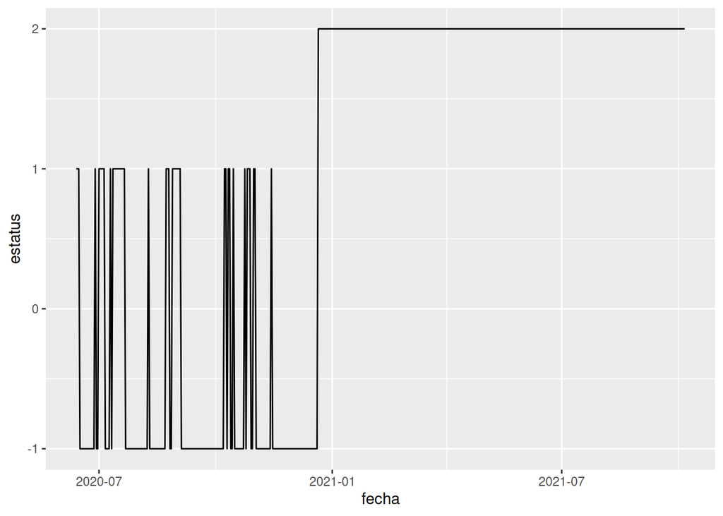

```r
p1 <- h1 %>%
      ggplot(mapping = aes(x=fecha,y= estatus)) +
      geom_line()
print(p1)
```

Podemos hacer las gráficas de todos los hospitales

```
## geom_path: Each group consists of only one observation. Do you need to adjust
## the group aesthetic?
```

[figure not shown]

```r
p2 <- datos %>%
      ggplot(mapping = aes(x=fecha, y = estatus)) +
      geom_path() +
      facet_wrap(~ Nombre_hospital) +
      theme(legend.position = "none",
            axis.text.x = element_text(size = 5, color = "red", angle = 45),
            axis.text.y = element_text(size = 5, color ="blue"),
            strip.text =  element_text(size = 5))
print(p2)
```